# BMIN503/EPID600 Project

Yifei Duan

### Overview

Goal: Use statistical and mathematical methods to analyze the COVID-19 spreading pattern in the past one year.

Data used in this Project: Package(“COVID19”) / Package(“covid19.analytics) / data[us_states]

Three faculties/Staff/Students: Mingjia Li: Candidate Ph.D in Perelman School of Medicine Shufan Lin: Candidate Ph.D in Bioengineering Department Bomyi Lim: Assistant Professor of Chemical and Biomolecular Engineering They helped me found the data resources used in this project. And they gave me some ideas how to use the data to do the analysis.

Link to the repo: https://github.com/ddyifei/BMIN503_Final_Project

### Introduction

Coronavirus disease (COVID-19) is an infectious disease caused by the SARS-CoV-2 virus. Most people infected with the virus will experience mild to moderate respiratory illness and recover without requiring special treatment. However, some will become seriously ill and require medical attention. Older people and those with underlying medical conditions like cardiovascular disease, diabetes, chronic respiratory disease, or cancer are more likely to develop serious illness. Anyone can get sick with COVID-19 and become seriously ill or die at any age. The COVID-19 pandemic is a formidable global public health challenge. Since the initial emergence of a novel coronavirus in late 2019, the spread of SARS-CoV-2 has been unrelenting, impacting nearly every aspect of society worldwide. The pandemic has required a substantial response by public health authorities at all levels.

As the pandemic continues to unfold across the United States and world, the consequences of inadequate preparation and implementation are abundantly clear. Despite decades of various commissions highlighting the threat of global pandemics and international planning for their inevitability, neither the United States nor the broader international system were ready to execute those plans and respond to a severe pandemic.

The COVID-19 pandemic is far from over and could yet evolve in unanticipated ways, but one of its most important lessons is already clear: preparation and early execution are essential in detecting, containing, and rapidly responding to and mitigating the spread of potentially dangerous emerging infectious diseases. Analyzing the trend of COVID-19 is a possible method to prevent the new spreading of COVID-19 pandemic. Analysis the pattern of COVID-19 in the past one year in the U.S. could help make the prediction of COVID-19 in the future.Different statistical methods will be used in this project to analyze the spreading situation of COVID-19 in the U.S. Mathematical methods and coding will be used for this project.

### Methods

```r
# install.packages("covid19.analytics")
```

```r
library("covid19.analytics")
library("dplyr")
library("spData")
library(sf)
```

In this project, I used COVID19 data provided by package(“COVID19”). This package provides a daily summary of COVID-19 cases, deaths, recovered, tests, vaccinations, and hospitalizations for 230+ countries, 760+ regions, and 12000+ administrative divisions of lower level. Includes policy measures, mobility data, and geospatial identifiers. This package can be found on the website: COVID-19 Data Hub https://covid19datahub.io

```r
# get the library of covid19 data
library("COVID19")
```

```r
library(leaflet)
library(RColorBrewer)
library(ggplot2)
library(sf)
```

The only function in the package is covid19(). By default, the function downloads worldwide data by country. But, you can choose the data from specific countries. What I did was that I put “US” argument in the covid19() function to extract all the data from US. Another argument I used in this function is “level”, which specifies the granularity of the data. In this case, level2 means the function can retrun state-level data. So, the code below will return the COVID19 data from US in a state-level.

```r
# get the covid19 data by US and for each state
covid19.us.state <- covid19(c("US"),level=2)
```

[output not shown]

```r
head(covid19.us.state)
```

```
##         id       date confirmed deaths recovered tests vaccines people_vaccinated people_fully_vaccinated hosp icu vent school_closing workplace_closing cancel_events gatherings_restrictions transport_closing stay_home_restrictions internal_movement_restrictions international_movement_restriction…
## 1 10b692cc 2020-03-16        NA     NA        NA    NA       NA                NA                      NA   NA  NA   NA             NA                NA            NA                      NA                NA                     NA                             NA                                  N…
## 2 10b692cc 2020-03-17        NA     NA        NA    NA       NA                NA                      NA   NA  NA   NA             NA                NA            NA                      NA                NA                     NA                             NA                                  N…
## 3 10b692cc 2020-03-18        NA     NA        NA    NA       NA                NA                      NA   NA  NA   NA             NA                NA            NA                      NA                NA                     NA                             NA                                  N…
## 4 10b692cc 2020-03-19        NA     NA        NA    NA       NA                NA                      NA   NA  NA   NA             NA                NA            NA                      NA                NA                     NA                             NA                                  N…
## 5 10b692cc 2020-03-20        NA     NA        NA    NA       NA                NA                      NA   NA  NA   NA             NA                NA            NA                      NA                NA                     NA                             NA                                  N…
## 6 10b692cc 2020-03-21        NA     NA        NA    NA       NA                NA                      NA   NA  NA   NA             NA                NA            NA                      NA                NA                     NA                             NA                                  N…
##   elderly_people_protection government_response_index stringency_index containment_health_index economic_support_index administrative_area_level administrative_area_level_1 administrative_area_level_2 administrative_area_level_3 latitude longitude population iso_alpha_3 iso_alpha_2 iso_numeric is…
## 1                        NA                        NA               NA                       NA                     NA                         2               United States    Northern Mariana Islands                        <NA> 14.15569  145.2119      55144         USA          US         840   …
## 2                        NA                        NA               NA                       NA                     NA                         2               United States    Northern Mariana Islands                        <NA> 14.15569  145.2119      55144         USA          US         840   …
## 3                        NA                        NA               NA                       NA                     NA                         2               United States    Northern Mariana Islands                        <NA> 14.15569  145.2119      55144         USA          US         840   …
## 4                        NA                        NA               NA                       NA                     NA                         2               United States    Northern Mariana Islands                        <NA> 14.15569  145.2119      55144         USA          US         840   …
## 5                        NA                        NA               NA                       NA                     NA                         2               United States    Northern Mariana Islands                        <NA> 14.15569  145.2119      55144         USA          US         840   …
## 6                        NA                        NA               NA                       NA                     NA                         2               United States    Northern Mariana Islands                        <NA> 14.15569  145.2119      55144         USA          US         840   …
```

“Confirmed” column and “administrative_area_level_2” columns were extracted from the COVID19 dataset. Column “confirmed” has the the total number of confirmed cases. “administrative_area_level_2” is the column which has the state name. And then the “administrative_area_level_2” renamed as “state” which is convenient to track the data.

```r
# get the date; confirmed cases and state column from the dataframe
covid19.confirmed.death <- covid19.us.state[, c("confirmed","administrative_area_level_2")]

# sort data
covid19.confirmed.death <- covid19.confirmed.death %>%
  arrange(administrative_area_level_2) %>%
  rename(state=administrative_area_level_2)
head(covid19.confirmed.death)
```

```
##   confirmed   state
## 1        NA Alabama
## 2        NA Alabama
## 3        NA Alabama
## 4        NA Alabama
## 5        NA Alabama
## 6        NA Alabama
```

Created another vector called “state.name” which contains all the names of the US states. Used a for loop to iterate this vector – state.name, and then filtered the whole dataset in which the state has the same name as in the for loop condition. Then used max to get the largest number of confirmed cases in each state. This number was stored in a vector called confirmed.number.

```r
# list of all State names
state.list <- state.name
# create a list which contain the data which show the highest number of confirmed cases in a day
confirmed.number <- c()

# get the highest confirmed cases in each state
for(name in state.list)
{
  # get the confirmed cases data by each state
  confirmed.cases.state <- covid19.confirmed.death %>% filter(state == name)
  # get highest number of the cases
  highest.number.case <- max(na.omit(confirmed.cases.state$confirmed))
  # add the number in to the list
  confirmed.number <- c(confirmed.number, highest.number.case)
}
```

Next step was to create another data frame called “confirmed.cases.by.state” which contains the name of each state in one column and the largest number of confirmed cases in each state. Then extracted the geometry data of each state from “data(us_states)[NAME}” and did the inner join with data frame “confirmed.cases.by.state” by state name.

```r
data(us_states)
# create a new dataset which only contains the confirmed case and state
confirmed.cases.by.state <- data.frame(state.list, confirmed.number)
head(confirmed.cases.by.state)
```

```
##   state.list confirmed.number
## 1    Alabama           850096
## 2     Alaska           151979
## 3    Arizona          1301597
## 4   Arkansas           535450
## 5 California          5141243
## 6   Colorado           854249
```

```r
nrow(confirmed.cases.by.state)
```

```
## [1] 50
```

```r
confirmed.cases.by.state <- confirmed.cases.by.state %>%
  rename(NAME=state.list)
nrow(confirmed.cases.by.state)
```

```
## [1] 50
```

```r
head(confirmed.cases.by.state)
```

```
##         NAME confirmed.number
## 1    Alabama           850096
## 2     Alaska           151979
## 3    Arizona          1301597
## 4   Arkansas           535450
## 5 California          5141243
## 6   Colorado           854249
```

```r
# get the geometry data in US
data(us_states)

# get the geometry data for each state
state.geo <- us_states["NAME"]
head(state.geo)
```

```
## Simple feature collection with 6 features and 1 field
## Geometry type: MULTIPOLYGON
## Dimension:     XY
## Bounding box:  xmin: -114.8136 ymin: 24.55868 xmax: -71.78699 ymax: 42.04964
## Geodetic CRS:  NAD83
##          NAME                       geometry
## 1     Alabama MULTIPOLYGON (((-88.20006 3...
## 2     Arizona MULTIPOLYGON (((-114.7196 3...
## 3    Colorado MULTIPOLYGON (((-109.0501 4...
## 4 Connecticut MULTIPOLYGON (((-73.48731 4...
## 5     Florida MULTIPOLYGON (((-81.81169 2...
## 6     Georgia MULTIPOLYGON (((-85.60516 3...
```

```r
# add this geometry data to the covid data set
confirmed.cases.by.state <- inner_join(x=state.geo, y=confirmed.cases.by.state, by="NAME")
head(confirmed.cases.by.state)
```

```
## Simple feature collection with 6 features and 2 fields
## Geometry type: MULTIPOLYGON
## Dimension:     XY
## Bounding box:  xmin: -114.8136 ymin: 24.55868 xmax: -71.78699 ymax: 42.04964
## Geodetic CRS:  NAD83
##          NAME confirmed.number                       geometry
## 1     Alabama           850096 MULTIPOLYGON (((-88.20006 3...
## 2     Arizona          1301597 MULTIPOLYGON (((-114.7196 3...
## 3    Colorado           854249 MULTIPOLYGON (((-109.0501 4...
## 4 Connecticut           433464 MULTIPOLYGON (((-73.48731 4...
## 5     Florida          3705899 MULTIPOLYGON (((-81.81169 2...
## 6     Georgia          1641485 MULTIPOLYGON (((-85.60516 3...
```

Used the data frame which was inner joined with “data(us_states)[”NAME”]”, an interactive map was created to show the confirmed cases so far in each state in the US. A scale bar was shown below as well.

```r
pal_fun <- colorNumeric("RdBu", NULL)

pu_message <- paste0("State: ", confirmed.cases.by.state$NAME, # paste0 to append tract name with other relevant text
"<br> Total Number of Confirmed Cases: ",confirmed.cases.by.state$confirmed.number)  # <br> forces new line

leaflet(confirmed.cases.by.state) %>%
  addPolygons(stroke = FALSE,                        # remove polygon borders
              fillColor = ~pal_fun(confirmed.number),
              fillOpacity = 1, smoothFactor = 1, # increase opacity and resolution
              popup = pu_message) %>%
  addProviderTiles(providers$CartoDB.Positron) %>%   # add third party provider tile
  addLegend("bottomright",                           # location of legend
            pal=pal_fun,                             # palette function
            values= ~confirmed.number,                 # variable to be passed to palette function
            title = 'Total number of confirmed cases',                  # legend title
            opacity = 1) %>%                         # legend opacity (1 = completely opaque)
  addScaleBar()
```

[interactive chart not shown]

“deaths” column and “administrative_area_level_2” columns were extracted from the COVID19 dataset. Column “deaths” has the the total number of deaths. “administrative_area_level_2” is the column which has the state name. And then the “administrative_area_level_2” renamed as “state” which is convenient to track the data.

```r
head(covid19.us.state)
```

```
##         id       date confirmed deaths recovered tests vaccines people_vaccinated people_fully_vaccinated hosp icu vent school_closing workplace_closing cancel_events gatherings_restrictions transport_closing stay_home_restrictions internal_movement_restrictions international_movement_restriction…
## 1 10b692cc 2020-03-16        NA     NA        NA    NA       NA                NA                      NA   NA  NA   NA             NA                NA            NA                      NA                NA                     NA                             NA                                  N…
## 2 10b692cc 2020-03-17        NA     NA        NA    NA       NA                NA                      NA   NA  NA   NA             NA                NA            NA                      NA                NA                     NA                             NA                                  N…
## 3 10b692cc 2020-03-18        NA     NA        NA    NA       NA                NA                      NA   NA  NA   NA             NA                NA            NA                      NA                NA                     NA                             NA                                  N…
## 4 10b692cc 2020-03-19        NA     NA        NA    NA       NA                NA                      NA   NA  NA   NA             NA                NA            NA                      NA                NA                     NA                             NA                                  N…
## 5 10b692cc 2020-03-20        NA     NA        NA    NA       NA                NA                      NA   NA  NA   NA             NA                NA            NA                      NA                NA                     NA                             NA                                  N…
## 6 10b692cc 2020-03-21        NA     NA        NA    NA       NA                NA                      NA   NA  NA   NA             NA                NA            NA                      NA                NA                     NA                             NA                                  N…
##   elderly_people_protection government_response_index stringency_index containment_health_index economic_support_index administrative_area_level administrative_area_level_1 administrative_area_level_2 administrative_area_level_3 latitude longitude population iso_alpha_3 iso_alpha_2 iso_numeric is…
## 1                        NA                        NA               NA                       NA                     NA                         2               United States    Northern Mariana Islands                        <NA> 14.15569  145.2119      55144         USA          US         840   …
## 2                        NA                        NA               NA                       NA                     NA                         2               United States    Northern Mariana Islands                        <NA> 14.15569  145.2119      55144         USA          US         840   …
## 3                        NA                        NA               NA                       NA                     NA                         2               United States    Northern Mariana Islands                        <NA> 14.15569  145.2119      55144         USA          US         840   …
## 4                        NA                        NA               NA                       NA                     NA                         2               United States    Northern Mariana Islands                        <NA> 14.15569  145.2119      55144         USA          US         840   …
## 5                        NA                        NA               NA                       NA                     NA                         2               United States    Northern Mariana Islands                        <NA> 14.15569  145.2119      55144         USA          US         840   …
## 6                        NA                        NA               NA                       NA                     NA                         2               United States    Northern Mariana Islands                        <NA> 14.15569  145.2119      55144         USA          US         840   …
```

```r
covid19.deaths.by.state <- covid19.us.state[, c("deaths","administrative_area_level_2")]

# sort data
covid19.deaths.by.state <- covid19.deaths.by.state %>%
  arrange(administrative_area_level_2) %>%
  rename(state=administrative_area_level_2)
head(covid19.deaths.by.state)
```

```
##   deaths   state
## 1     NA Alabama
## 2     NA Alabama
## 3     NA Alabama
## 4     NA Alabama
## 5     NA Alabama
## 6     NA Alabama
```

Used another vector called “state.name” which was created above and this vector contains all the names of the US states. Used a for loop to iterate this vector – state.name, and then filtered the whole dataset in which the state has the same name as in the for loop condition. Then used max to get the total number of deaths in each state. This number was stored in a vector called deaths.state.

```r
deaths.state <- c()

for(name in state.list)
{
  # get the confirmed cases data by each state
  data.by.state <- covid19.deaths.by.state %>% filter(state == name)
  deaths.number <- max(na.omit(data.by.state$deaths))

  deaths.state <- c(deaths.state, deaths.number)
}

total.deaths.by.state <- data.frame(state.list, deaths.state)
total.deaths.by.state <- total.deaths.by.state %>% rename(NAME = state.list)
total.deaths.by.state
```

```
##              NAME deaths.state
## 1         Alabama        16203
## 2          Alaska          862
## 3         Arizona        22779
## 4        Arkansas         8796
## 5      California        75279
## 6        Colorado         9694
## 7     Connecticut         8946
## 8        Delaware         2206
## 9         Florida        61789
## 10        Georgia        29634
## 11         Hawaii         1036
## 12          Idaho         4002
## 13       Illinois        29734
## 14        Indiana        17909
```

[output cut: 36 more lines]

Next step was to create another data frame called “total.deaths.by.state” which contains the name of each state in one column and the total number of deaths in each state. Then extracted the geometry data of each state from “data(us_states)[NAME}” and did the inner join with data frame “total.deaths.by.state” by state name. Used the data frame which was inner joined with “data(us_states)[”NAME”]”, an interactive map was created to show the total number of deaths so far in each state in the US. A scale bar was shown below as well.

```r
head(state.geo)
```

```
## Simple feature collection with 6 features and 1 field
## Geometry type: MULTIPOLYGON
## Dimension:     XY
## Bounding box:  xmin: -114.8136 ymin: 24.55868 xmax: -71.78699 ymax: 42.04964
## Geodetic CRS:  NAD83
##          NAME                       geometry
## 1     Alabama MULTIPOLYGON (((-88.20006 3...
## 2     Arizona MULTIPOLYGON (((-114.7196 3...
## 3    Colorado MULTIPOLYGON (((-109.0501 4...
## 4 Connecticut MULTIPOLYGON (((-73.48731 4...
## 5     Florida MULTIPOLYGON (((-81.81169 2...
## 6     Georgia MULTIPOLYGON (((-85.60516 3...
```

```r
# inner join the state geometry data and deaths data
total.deaths.by.state <- inner_join(x=state.geo, y=total.deaths.by.state, by="NAME")
head(total.deaths.by.state)
```

```
## Simple feature collection with 6 features and 2 fields
## Geometry type: MULTIPOLYGON
## Dimension:     XY
## Bounding box:  xmin: -114.8136 ymin: 24.55868 xmax: -71.78699 ymax: 42.04964
## Geodetic CRS:  NAD83
##          NAME deaths.state                       geometry
## 1     Alabama        16203 MULTIPOLYGON (((-88.20006 3...
## 2     Arizona        22779 MULTIPOLYGON (((-114.7196 3...
## 3    Colorado         9694 MULTIPOLYGON (((-109.0501 4...
## 4 Connecticut         8946 MULTIPOLYGON (((-73.48731 4...
## 5     Florida        61789 MULTIPOLYGON (((-81.81169 2...
## 6     Georgia        29634 MULTIPOLYGON (((-85.60516 3...
```

```r
pal_fun <- colorNumeric("RdPu", NULL)

pu_message <- paste0("State: ", total.deaths.by.state$NAME, # paste0 to append tract name with other relevant text
"<br> Total Number of Deaths: ",total.deaths.by.state$deaths.state)  # <br> forces new line

leaflet(total.deaths.by.state) %>%
  addPolygons(stroke = FALSE,                        # remove polygon borders
              fillColor = ~pal_fun(deaths.state),
              fillOpacity = 1, smoothFactor = 1, # increase opacity and resolution
              popup = pu_message) %>%
  addProviderTiles(providers$CartoDB.Positron) %>%   # add third party provider tile
  addLegend("bottomright",                           # location of legend
            pal=pal_fun,                             # palette function
            values= ~deaths.state,                 # variable to be passed to palette function
            title = 'Total number of confirmed cases',                  # legend title
            opacity = 1) %>%                         # legend opacity (1 = completely opaque)
  addScaleBar()
```

[interactive chart not shown]

“tests” column and “administrative_area_level_2” columns were extracted from the COVID19 dataset. Column “tests” has the the total number of tests on each state. “administrative_area_level_2” is the column which has the state name. And then the “administrative_area_level_2” renamed as “state” which is convenient to track the data.

```r
covid19.tests.by.state <- covid19.us.state[, c("tests","administrative_area_level_2")]
head(covid19.tests.by.state)
```

```
##   tests administrative_area_level_2
## 1    NA    Northern Mariana Islands
## 2    NA    Northern Mariana Islands
## 3    NA    Northern Mariana Islands
## 4    NA    Northern Mariana Islands
## 5    NA    Northern Mariana Islands
## 6    NA    Northern Mariana Islands
```

```r
covid19.tests.by.state <- covid19.tests.by.state %>%
  arrange(administrative_area_level_2) %>%
  rename(state=administrative_area_level_2)
head(covid19.tests.by.state)
```

```
##   tests   state
## 1    NA Alabama
## 2    NA Alabama
## 3    NA Alabama
## 4    NA Alabama
## 5    NA Alabama
## 6    NA Alabama
```

Used another vector called “state.name” which was created above and this vector contains all the names of the US states. Used a for loop to iterate this vector – state.name, and then filtered the whole dataset in which the state has the same name as in the for loop condition. Then used max to get the total number of tests in each state. This number was stored in a vector called tests.state.

```r
tests.state <- c()

for(name in state.list)
{
  # get the total number of tests data by each state
  tests.number.by.state <- covid19.tests.by.state %>% filter(state == name)
  total.tests.number <- max(na.omit(tests.number.by.state$tests))

  tests.state <- c(tests.state, total.tests.number)
}

total.tests.by.state <- data.frame(state.list, tests.state)
total.tests.by.state <- total.tests.by.state %>% rename(NAME = state.list, total.tests.number = tests.state)
head(total.tests.by.state)
```

```
##         NAME total.tests.number
## 1    Alabama            6342133
## 2     Alaska            3032062
## 3    Arizona           11820441
## 4   Arkansas            3912057
## 5 California           97433141
## 6   Colorado           12119601
```

Used the data frame which was inner joined with “data(us_states)[”NAME”]”, an interactive map was created to show the total number of tests so far in each state in the US. A scale bar was shown below as well.

```r
total.tests.by.state <- inner_join(x=state.geo, y=total.tests.by.state, by="NAME")
head(total.deaths.by.state)
```

```
## Simple feature collection with 6 features and 2 fields
## Geometry type: MULTIPOLYGON
## Dimension:     XY
## Bounding box:  xmin: -114.8136 ymin: 24.55868 xmax: -71.78699 ymax: 42.04964
## Geodetic CRS:  NAD83
##          NAME deaths.state                       geometry
## 1     Alabama        16203 MULTIPOLYGON (((-88.20006 3...
## 2     Arizona        22779 MULTIPOLYGON (((-114.7196 3...
## 3    Colorado         9694 MULTIPOLYGON (((-109.0501 4...
## 4 Connecticut         8946 MULTIPOLYGON (((-73.48731 4...
## 5     Florida        61789 MULTIPOLYGON (((-81.81169 2...
## 6     Georgia        29634 MULTIPOLYGON (((-85.60516 3...
```

```r
pal_fun <- colorNumeric("OrRd", NULL)

pu_message <- paste0("State: ", total.tests.by.state$NAME, # paste0 to append tract name with other relevant text
"<br> Total Number of tests: ",total.tests.by.state$total.tests.number)  # <br> forces new line

leaflet(total.tests.by.state) %>%
  addPolygons(stroke = FALSE,                        # remove polygon borders
              fillColor = ~pal_fun(total.tests.number),
              fillOpacity = 1, smoothFactor = 1, # increase opacity and resolution
              popup = pu_message) %>%
  addProviderTiles(providers$CartoDB.Positron) %>%   # add third party provider tile
  addLegend("bottomright",                           # location of legend
            pal=pal_fun,                             # palette function
            values= ~total.tests.number,                 # variable to be passed to palette function
            title = 'Total number of confirmed cases',                  # legend title
            opacity = 1) %>%                         # legend opacity (1 = completely opaque)
  addScaleBar()
```

[interactive chart not shown]

```r
covid19.tests.by.state <- covid19.us.state[, c("vaccines","administrative_area_level_2")]
head(covid19.tests.by.state)
```

```
##   vaccines administrative_area_level_2
## 1       NA    Northern Mariana Islands
## 2       NA    Northern Mariana Islands
## 3       NA    Northern Mariana Islands
## 4       NA    Northern Mariana Islands
## 5       NA    Northern Mariana Islands
## 6       NA    Northern Mariana Islands
```

```r
covid19.tests.by.state <- covid19.tests.by.state %>%
  arrange(administrative_area_level_2) %>%
  rename(state=administrative_area_level_2)
head(covid19.tests.by.state)
```

```
##   vaccines   state
## 1       NA Alabama
## 2       NA Alabama
## 3       NA Alabama
## 4       NA Alabama
## 5       NA Alabama
## 6       NA Alabama
```

```r
vaccines.state <- c()

for(name in state.list)
{
  # get the total number of tests data by each state
  vaccines.number.by.state <- covid19.tests.by.state %>% filter(state == name)
  total.vaccines.number <- max(na.omit(vaccines.number.by.state$vaccines))

  vaccines.state <- c(vaccines.state, total.vaccines.number)
}

total.vaccines.by.state <- data.frame(state.list, vaccines.state)
total.vaccines.by.state <- total.vaccines.by.state %>% rename(NAME = state.list)
head(total.vaccines.by.state)
```

```
##         NAME vaccines.state
## 1    Alabama        5379834
## 2     Alaska         985628
## 3    Arizona        9908217
## 4   Arkansas        3633151
## 5 California       61693063
## 6   Colorado        8940101
```

```r
total.vaccines.by.state <- inner_join(x=state.geo, y=total.vaccines.by.state, by="NAME")

pal_fun <- colorNumeric("Greens", NULL)

pu_message <- paste0("State: ", total.vaccines.by.state$NAME, # paste0 to append tract name with other relevant text
"<br> Total Number of vaccinations: ",total.vaccines.by.state$vaccines.state)  # <br> forces new line

leaflet(total.vaccines.by.state) %>%
  addPolygons(stroke = FALSE,                        # remove polygon borders
              fillColor = ~pal_fun(vaccines.state),
              fillOpacity = 1, smoothFactor = 1, # increase opacity and resolution
              popup = pu_message) %>%
  addProviderTiles(providers$CartoDB.Positron) %>%   # add third party provider tile
  addLegend("bottomright",                           # location of legend
            pal=pal_fun,                             # palette function
            values= ~vaccines.state,                 # variable to be passed to palette function
            title = 'Total number of confirmed cases',                  # legend title
            opacity = 1) %>%                         # legend opacity (1 = completely opaque)
  addScaleBar()
```

[interactive chart not shown]

Another package I uased in this project is library(“covid19.analytics”).This package also provides worldwide COVID19 data. But this package includes lots of number of functions.

```r
library("covid19.analytics")
```

The function covid19.data() can return worldwide data. By using argument ‘ts-confirmed’, this covid19.data function will return the total number of confirmed cases.

```r
# get the data of confirmed cases globally from dataset
covid19.confirmed.cases <- covid19.data('ts-confirmed')
```

```
## Data being read from JHU/CCSE repository
```

```
## ~~~~~~~~~~~~~~~~~~~~~~~~~~~~~~~~~~~~~~~~~~~~~~~~~~~~~~~~~~~~~~~~~~~~~~~~~~~~~~~~
```

```
## Reading data from https://raw.githubusercontent.com/CSSEGISandData/COVID-19/master/csse_covid_19_data/csse_covid_19_time_series/time_series_covid19_confirmed_global.csv
```

```
## Data retrieved on 2021-12-10 20:17:28 || Range of dates on data: 2020-01-22--2021-12-09 | Nbr of records: 280
```

```r
covid19.confirmed.cases_us <- covid19.confirmed.cases %>%
  filter(Country.Region == "US")

# show the trend of increasing number of confirmed cases
tots.per.location(covid19.confirmed.cases_us)
```

```
## US  --  49661145
## ===============================   running models...===============================
##   Linear Regression (lm):
##
## Call:
## lm(formula = y.var ~ x.var)
##
## Residuals:
##      Min       1Q   Median       3Q      Max
## -6093606 -2342718   515086  2461841  7706337
##
## Coefficients:
##             Estimate Std. Error t value Pr(>|t|)
## (Intercept) -7787365     247348  -31.48   <2e-16 ***
## x.var          81029        622  130.27   <2e-16 ***
## ---
## Signif. codes:  0 '***' 0.001 '**' 0.01 '*' 0.05 '.' 0.1 ' ' 1
##
## Residual standard error: 3240000 on 686 degrees of freedom
## Multiple R-squared:  0.9611, Adjusted R-squared:  0.9611
## F-statistic: 1.697e+04 on 1 and 686 DF,  p-value: < 2.2e-16
##
## --------------------------------------------------------------------------------
##   Linear Regression (lm):
##
## Call:
## lm(formula = y.var ~ x.var)
##
## Residuals:
##     Min      1Q  Median      3Q     Max
## -9.7898 -1.0536  0.9442  1.7724  2.2005
##
## Coefficients:
##              Estimate Std. Error t value Pr(>|t|)
## (Intercept) 1.046e+01  1.994e-01   52.44   <2e-16 ***
## x.var       1.395e-02  5.014e-04   27.82   <2e-16 ***
## ---
## Signif. codes:  0 '***' 0.001 '**' 0.01 '*' 0.05 '.' 0.1 ' ' 1
##
## Residual standard error: 2.612 on 686 degrees of freedom
```

[output cut: 39 more lines]

```
##              Estimate Std. Error t value Pr(>|t|)
## (Intercept) 1.342e+01  4.483e-02  299.30   <2e-16 ***
## x.var       7.978e-03  1.127e-04   70.77   <2e-16 ***
## ---
## Signif. codes:  0 '***' 0.001 '**' 0.01 '*' 0.05 '.' 0.1 ' ' 1
##
## (Dispersion parameter for Gamma family taken to be 0.3448685)
##
##     Null deviance: 2152.2  on 687  degrees of freedom
## Residual deviance: 1254.3  on 686  degrees of freedom
## AIC: 23555
##
## Number of Fisher Scoring iterations: 16
##
## --------------------------------------------------------------------------------
```

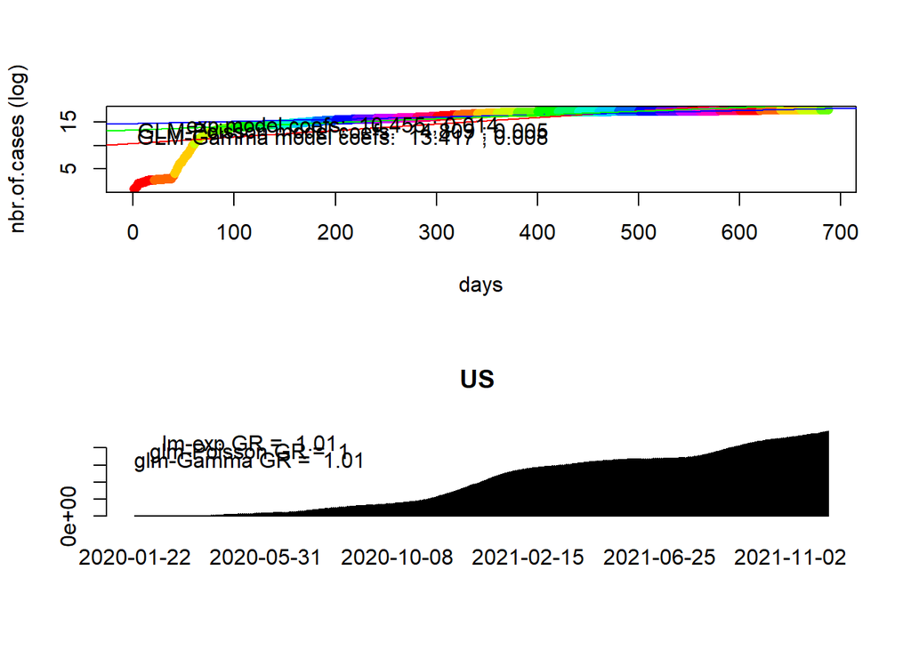

```r
# get the growth rate of cases in the US.(Total growth )
TS.data <- covid19.data("ts-confirmed")
```

```
## Data being read from JHU/CCSE repository
```

```
## ~~~~~~~~~~~~~~~~~~~~~~~~~~~~~~~~~~~~~~~~~~~~~~~~~~~~~~~~~~~~~~~~~~~~~~~~~~~~~~~~
```

```
## Reading data from https://raw.githubusercontent.com/CSSEGISandData/COVID-19/master/csse_covid_19_data/csse_covid_19_time_series/time_series_covid19_confirmed_global.csv
```

```
## Data retrieved on 2021-12-10 20:17:29 || Range of dates on data: 2020-01-22--2021-12-09 | Nbr of records: 280
```

```r
growth.rate(TS.data, geo.loc="US")
```

```
## Processing...  US
```

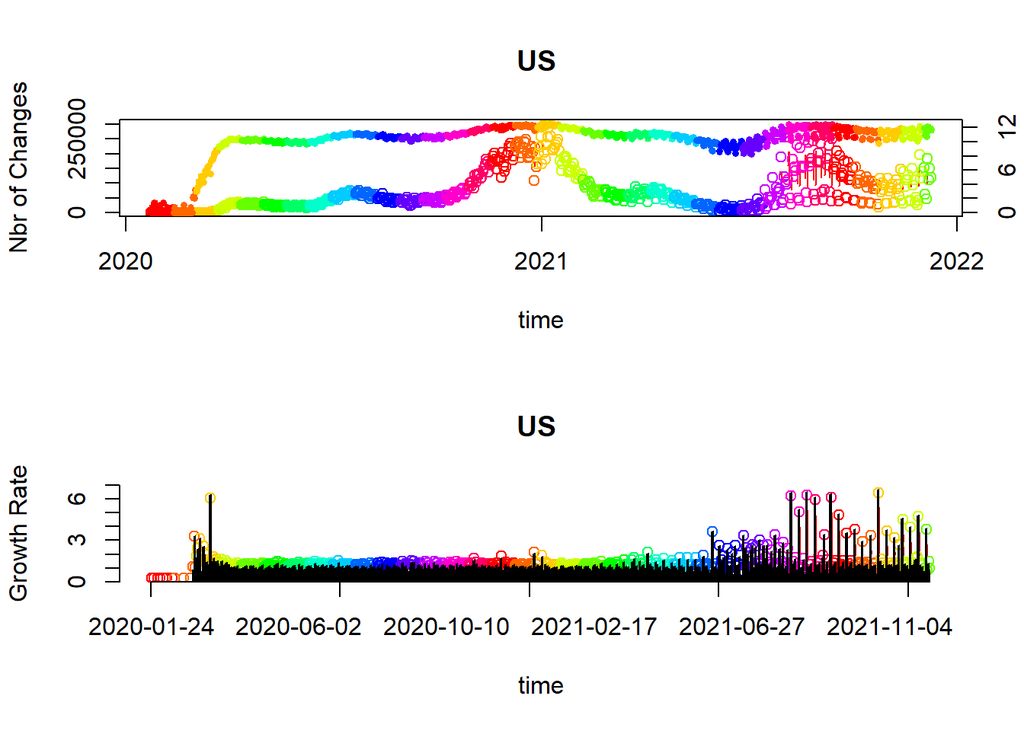

[output not shown]

[output cut: 66 more lines]